# Assignment 3

# Number of late days used

[figure not shown]

## 1. Differentiable Volume Rendering

### 1.3. Ray sampling (10 points)

**Implementation**  
**1. get_pixels_from_image in ray_utils.py and**  
**2. get_rays_from_pixels in ray_utils.py**

```python
# Generate pixel coordinates from in NDC space (from [-1, 1])
def get_pixels_from_image(image_size, camera):
    W, H = image_size[0], image_size[1]

    # TODO (1.3): Generate pixel coordinates from [0, W] in x and [0, H] in y
    x = torch.arange(0,W)
    y = torch.arange(0,H)
    # pass

    # TODO (1.3): Convert to the range [-1, 1] in both x and y
    x = (2.0 * x / W) - 1.0
    y = (2.0 * y / H) - 1.0
    # pass

    # Create grid of coordinates
    xy_grid = torch.stack(
        tuple( reversed( torch.meshgrid(y, x) ) ),
        dim=-1,
    ).view(W * H, 2)

    return -xy_grid
```

```python
# Get rays from pixel values
def get_rays_from_pixels(xy_grid, image_size, camera):
    W, H = image_size[0], image_size[1]

    # TODO (1.3): Map pixels to points on the image plane at Z=1
    device = get_device()
    ndc_points = xy_grid.to(device)
    # pass

    ndc_points = torch.cat(
        [
            ndc_points,
            torch.ones_like(ndc_points[..., -1:])
        ],
        dim=-1
    )

    # TODO (1.3): Use camera.unproject to get world space points on the image plane from NDC space points
    ndc_to_world = camera.unproject_points(ndc_points, world_coordinates=True)
    # pass

    # TODO (1.3): Get ray origins from camera center
    rays_o = camera.get_camera_center() * torch.ones_like(ndc_points)
    # pass

    # TODO (1.3): Get normalized ray directions
    rays_d = torch.nn.functional.normalize(ndc_to_world - rays_o)
    # pass

    # Create and return RayBundle
    return RayBundle(
        rays_o,
        rays_d,
        torch.zeros_like(rays_o).unsqueeze(1),
        torch.zeros_like(rays_o).unsqueeze(1),
    )
```

**Visualization**

Code in main.py:

```python
# TODO (1.3): Visualize xy grid using vis_grid
    W, H = image_size[0], image_size[1]

    if cam_idx == 0 and file_prefix == '':
        # pass
        image = xy_grid.cpu().numpy().reshape(W,H,2)
        image  = (image + 1 )/ 2.0
        image = np.absolute(image)
        image = np.concatenate((image, np.zeros((W,H,1))), axis = -1)
        plt.figure(figsize=(10, 10))
        plt.imshow(image)
        plt.imsave('vis_grid.png',image)
        plt.axis("off")

    # TODO (1.3): Visualize rays using vis_rays
    if cam_idx == 0 and file_prefix == '':
        # pass
        rays_d = ray_bundle.directions
        image = rays_d.cpu().numpy().reshape(W,H,3)
        image = np.absolute(image)
        plt.figure(figsize=(10, 10))
        plt.imshow(image)
        plt.imsave('vis_rays.png',image)
        plt.axis("off")
```

xy_grid visualization:

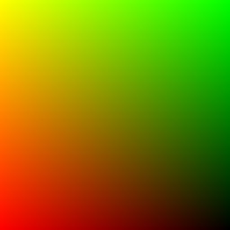

rays visualization:

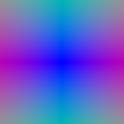

### 1.4. Point sampling (10 points)

**Implementation**  
**To fill out StratifiedSampler in sampler.py.**

```python
# Sampler which implements stratified (uniform) point sampling along rays
class StratifiedRaysampler(torch.nn.Module):
    def __init__(
        self,
        cfg
    ):
        super().__init__()

        self.n_pts_per_ray = cfg.n_pts_per_ray
        self.min_depth = cfg.min_depth
        self.max_depth = cfg.max_depth

    def forward(
        self,
        ray_bundle,
    ):
        # TODO (1.4): Compute z values for self.n_pts_per_ray points uniformly sampled between [near, far]
        z_vals = torch.linspace(self.min_depth, self.max_depth, self.n_pts_per_ray, device = get_device())

        # TODO (1.4): Sample points from z values
        num_rays = ray_bundle.origins.shape[0]                                     # 65536
        sample_points = torch.zeros((num_rays, self.n_pts_per_ray, 3), device = get_device())  # (65536, 64, 3)

        # p = z * dir + p0

        z_vals = torch.ones((num_rays,1)).to(get_device()) @ z_vals.reshape(1, -1)   # torch.Size([65536, 64])
        z_vals = z_vals.unsqueeze(2)       # torch.Size([65536, 64, 1])

        for i in range(self.n_pts_per_ray):
            sample_points[:,i,:] = ray_bundle.directions

        sample_points = z_vals * sample_points
        for i in range(self.n_pts_per_ray):
            sample_points[:,i,:] = sample_points[:,i,:] + ray_bundle.origins

        # Return
        return ray_bundle._replace(
            sample_points=sample_points,
            sample_lengths=z_vals * torch.ones_like(sample_points[..., :1]),
        )
```

**Visualization**

Code in main.py:

```python
# TODO (1.4): Implement point sampling along rays in sampler.py
        ray_bundle_modified = model.sampler.forward(ray_bundle)
        # pass

        # TODO (1.4): Visualize sample points as point cloud
        if cam_idx == 0 and file_prefix == '':
            render_points('render_points.png', ray_bundle_modified.sample_points.view(-1,3)[None],
                          image_size=256, color=[0.7, 0.7, 1], device=device)
```

Point samples from the first camera:

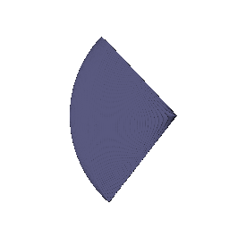

### 1.5. Volume rendering (30 points)

**Implementation**  
**1. VolumeRenderer._compute_weights**  
**2. VolumeRenderer._aggregate**  
**3. Modify the VolumeRenderer.forward method to render a depth map in addition to color from a volume.**

```python
def _compute_weights(
        self,
        deltas,
        rays_density: torch.Tensor,
        eps: float = 1e-10
    ):
        # TODO (1.5): Compute transmittance using the equation described in the README
        # pass
        num_rays, n_sample_per_ray = deltas.shape[0], deltas.shape[1]

        T = torch.ones(num_rays, n_sample_per_ray,1).to(get_device())
        factor = torch.exp(-(deltas * rays_density))

        for i in range(1, n_sample_per_ray):
            T[:,i,:] = T[:,i-1,:].clone() * factor[:,i-1,:]

        # TODO (1.5): Compute weight used for rendering from transmittance and density
        weights = T * (1-factor)

        return weights
```

```python
def _aggregate(
        self,
        weights: torch.Tensor,
        rays_feature: torch.Tensor
    ):
        # TODO (1.5): Aggregate (weighted sum of) features using weights
        # pass
        feature = torch.sum(weights * rays_feature, dim=1)

        return feature
```

```python
def forward(
        self,
        sampler,
        implicit_fn,
        ray_bundle,
    ):
        B = ray_bundle.shape[0]

        # Process the chunks of rays.
        chunk_outputs = []

        for chunk_start in range(0, B, self._chunk_size):
            cur_ray_bundle = ray_bundle[chunk_start:chunk_start+self._chunk_size]

            # Sample points along the ray
            cur_ray_bundle = sampler(cur_ray_bundle)
            n_pts = cur_ray_bundle.sample_shape[1]

            # Call implicit function with sample points
            implicit_output = implicit_fn(cur_ray_bundle)
            density = implicit_output['density']
            feature = implicit_output['feature']

            # Compute length of each ray segment
            depth_values = cur_ray_bundle.sample_lengths[..., 0]
            deltas = torch.cat(
                (
                    depth_values[..., 1:] - depth_values[..., :-1],
                    1e10 * torch.ones_like(depth_values[..., :1]),
                ),
                dim=-1,
            )[..., None]

            # Compute aggregation weights
            weights = self._compute_weights(
                deltas.view(-1, n_pts, 1),
                density.view(-1, n_pts, 1)
            )

            # TODO (1.5): Render (color) features using weights
            # pass
            feature = self._aggregate(weights, feature.view(-1, n_pts, 3))

            # TODO (1.5): Render depth map
            # pass
            depth = self._aggregate(weights, depth_values.view(-1, n_pts, 1))

            # Return
            cur_out = {
                'feature': feature,
                'depth': depth,
            }

            chunk_outputs.append(cur_out)

        # Concatenate chunk outputs
        out = {
            k: torch.cat(
              [chunk_out[k] for chunk_out in chunk_outputs],
              dim=0
            ) for k in chunk_outputs[0].keys()
        }

        return out
```

**Visualization**

```python
# TODO (1.5): Implement rendering in renderer.py
out = model(ray_bundle)

# Return rendered features (colors)
image = np.array(out['feature'].view(image_size[1], image_size[0], 3).detach().cpu())
all_images.append(image)

# TODO (1.5): Visualize depth
if cam_idx == 2 and file_prefix == '':
# pass
    depth = np.array(out['depth'].view(image_size[1], image_size[0]).detach().cpu())
    plt.imsave(f'{file_prefix}_{cam_idx}_depth.png',depth, cmap = 'plasma')
```

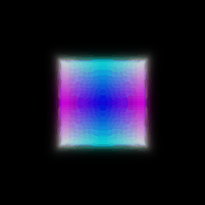

Depth Map:

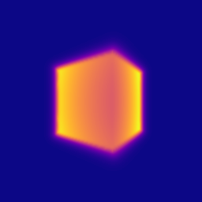

## 2. Optimizing a basic implicit volume

### 2.1. Random ray sampling (5 points)

**Implement the get_random_pixels_from_image method in ray_utils.py**

```python
def get_random_pixels_from_image(n_pixels, image_size, camera):
    xy_grid = get_pixels_from_image(image_size, camera)

    # TODO (2.1): Random subsampling of pixel coordinates
    x_sampled = torch.rand(n_pixels)*2.0 - 1.0
    y_sampled = torch.rand(n_pixels)*2.0 - 1.0
    xy_grid_sub = torch.stack((x_sampled,y_sampled),dim = 1).to(get_device())

    # Return
    return xy_grid_sub.reshape(-1, 2)[:n_pixels]
```

### 2.2. Loss and training (5 points)

**Replace the loss in train with mean squared error between the predicted colors and ground truth colors rgb_gt**

```python
# TODO (2.2): Calculate loss

predicted = out['feature']
# print('out', predicted.shape)
mse_loss = torch.nn.MSELoss()
loss = mse_loss(predicted, rgb_gt)
```

**Report the center of the box, and the side lengths of the box after training, rounded to the nearest 1/100 decimal place.**

Box center: [0.25, 0.25, 0.00].  
Box side lengths: [2.00, 1.50, 1.50]

**Visualization**

Render of a spiral sequence of the optimized volume:

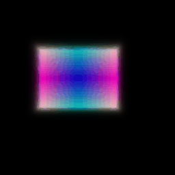

## 3. Optimizing a Neural Radiance Field (NeRF) (30 points)

**Implementation**  
**An implicit volume as a Multi-Layer Perceptron (MLP) in the NeuraRadianceField class in implicit.py.**  
**Fill out the loss in train_nerf in the main.py file.**

```python
# TODO (3.1): Implement NeRF MLP
class NeuralRadianceField(torch.nn.Module):
    def __init__(
        self,
        cfg,
    ):
        super().__init__()

        self.harmonic_embedding_xyz = HarmonicEmbedding(3, cfg.n_harmonic_functions_xyz)
        self.harmonic_embedding_dir = HarmonicEmbedding(3, cfg.n_harmonic_functions_dir)

        embedding_dim_xyz = self.harmonic_embedding_xyz.output_dim
        embedding_dim_dir = self.harmonic_embedding_dir.output_dim

        # pass
        self.cfg = cfg

        embedding_dim = embedding_dim_xyz                      # 39
        hidden_dim = cfg.n_hidden_neurons_xyz                  # 128

        self.in_layer = torch.nn.Linear(embedding_dim, hidden_dim)
        self.hidden = torch.nn.Linear(hidden_dim, hidden_dim)

        # seperate output tail
        self.out_density = torch.nn.Linear(hidden_dim, 1)
        self.out_color = torch.nn.Linear(hidden_dim, 3)

        self.relu = torch.nn.functional.relu
        self.sigmoid = torch.sigmoid

    def forward(self, ray_bundle):
        sample_points = ray_bundle.sample_points.view(-1, 3)
        embedded_xyz = self.harmonic_embedding_xyz(sample_points)

        x = embedded_xyz                                 # torch.Size([131072, 39])

        x = self.in_layer(x)                               # torch.Size([131072, 128])
        # print(f"x_shape_after 1 pass: {x.shape}")

        for _ in range(self.cfg.n_layers_xyz-2):
            x = self.relu(self.hidden(x))

        density = self.relu(self.out_density(x))
        color = self.sigmoid(self.out_color(x))

        out = {
            'density': density,
            'feature': color,
        }

        return out
```

```python
# TODO (3.1): Calculate loss

predicted = out['feature']
mse_loss = torch.nn.MSELoss()
loss = mse_loss(predicted, rgb_gt)
```

**Visualization**

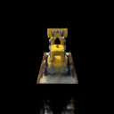

## 4. NeRF Extras (Choose at least one! More than one is extra credit)

### 4.1 View Dependence (10 pts)

Code of the network:

```python
class NeuralRadianceField(torch.nn.Module):
    def __init__(
        self,
        cfg,
    ):
        super().__init__()

        self.harmonic_embedding_xyz = HarmonicEmbedding(3, cfg.n_harmonic_functions_xyz)
        self.harmonic_embedding_dir = HarmonicEmbedding(3, cfg.n_harmonic_functions_dir)

        embedding_dim_xyz = self.harmonic_embedding_xyz.output_dim
        embedding_dim_dir = self.harmonic_embedding_dir.output_dim

        # pass
        self.cfg = cfg

        embedding_dim = embedding_dim_dir + embedding_dim_xyz       # 54
        # print(f"embedding_dim: {embedding_dim}")

        hidden_dim = cfg.n_hidden_neurons_xyz             # 128

        self.in_layer = torch.nn.Linear(embedding_dim, hidden_dim)
        self.hidden = torch.nn.Linear(hidden_dim, hidden_dim)

        self.out_density = torch.nn.Linear(hidden_dim, 1)
        self.out_color = torch.nn.Linear(hidden_dim, 3)

        self.relu = torch.nn.functional.relu
        self.sigmoid = torch.sigmoid

    def forward(self, ray_bundle):
        sample_points = ray_bundle.sample_points.view(-1, 3)
        embedded_xyz = self.harmonic_embedding_xyz(sample_points)

        directions = ray_bundle.directions.view(-1, 3)            #4.1
        embedded_dir = self.harmonic_embedding_dir(directions)    #4.1    torch.Size([1024, 15])
        # import ipdb; ipdb.set_trace()
        embedded_dir = embedded_dir.unsqueeze(1).repeat(1, 128, 1).reshape((-1,15))
        x = torch.cat((embedded_xyz, embedded_dir), dim=-1)       #4.1
        # print(f"x_shape: {x.shape}")


        x = self.in_layer(x)                               # torch.Size([131072, 128])
        # print(f"x_shape_after 1 pass: {x.shape}")

        for _ in range(self.cfg.n_layers_xyz-2):
            x = self.relu(self.hidden(x))

        density = self.relu(self.out_density(x))
        color = self.sigmoid(self.out_color(x))

        out = {
            'density': density,
            'feature': color,
        }

        return out
```

**Visualization**

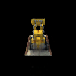